# set up and import data

# heatmap visual

Heatmap: Fraction of each row transcription factors’ peaks that are co-occupied by the column transcription factor. The example heatmap below shows IRF4 as regulatee in TexTerm

[figure not shown]

```r
pheatmap(data2, color = colorRampPalette(brewer.pal(n = 9, name = "Reds"))(10), main = 'Regulators of IRF4 in TexTerm')
```

Heatmap showing the top10 TFs most related to PRDM1 based on coverage of peaks. The example heatmap below shows IRF4 as regulatee in TexTerm

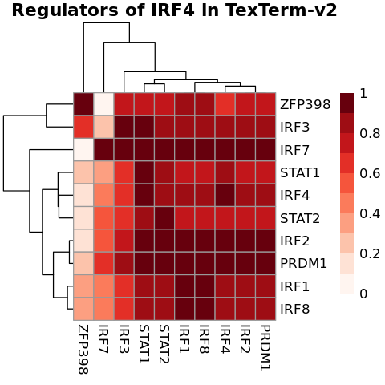

```r
options(repr.plot.width=4, repr.plot.height=4)
p1 <- pheatmap(data3, color = colorRampPalette(brewer.pal(n = 9, name = "Reds"))(10), main = 'Regulators of IRF4 in TexTerm-v2')
```

```r
## prepare data for bar plot
data3l <- data3 |> tibble::rownames_to_column('row') |> tidyr::pivot_longer(!row,names_to = 'column', values_to = 'coverage')
head(data3l)
dim(data3l)
```

A tibble: 6 × 3

| row <chr> | column <chr> | coverage <dbl> |
| --- | --- | --- |
| ZFP398 | ZFP398 | 1.0000000 |
| ZFP398 | IRF7 | 0.0000000 |
| ZFP398 | IRF3 | 0.7500000 |
| ZFP398 | IRF1 | 0.8333333 |
| ZFP398 | IRF2 | 0.7500000 |
| ZFP398 | IRF4 | 0.6666667 |

1. 100

2. 3

```r
# PRDM1 peaks cobound by other TFs
data3l1 <- data3l |> filter(row=='PRDM1') |> arrange(coverage)
data3l1$column <- factor(data3l1$column, levels = data3l1$column)

# TF peaks cobound by PRDM1
data3l2 <- data3l |> filter(column=='PRDM1') |> arrange(coverage)
data3l2$row <- factor(data3l2$row, levels = data3l2$row)
```

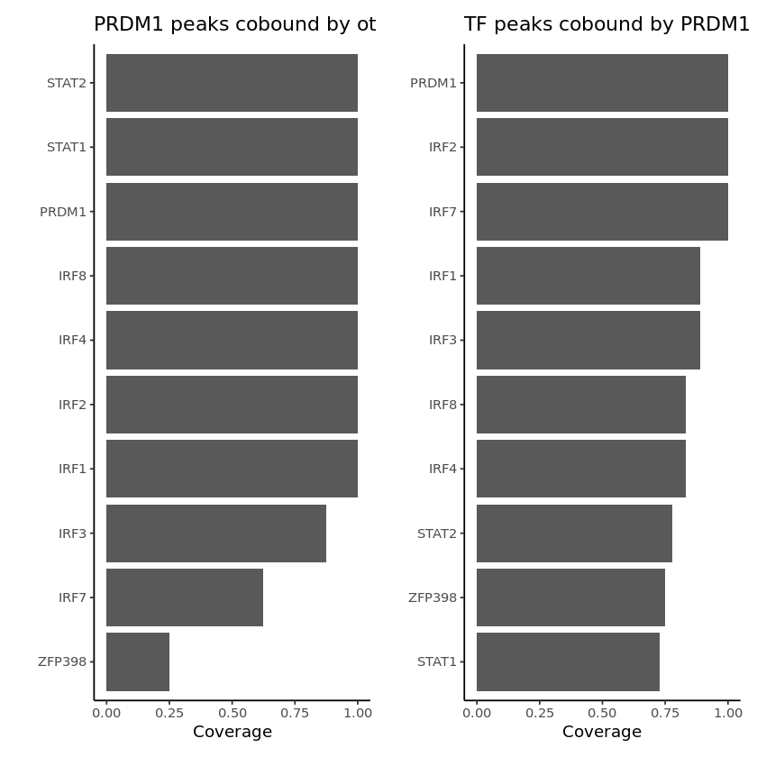

```r
library(patchwork)
p2 <- ggplot(data = data3l1, aes(x=coverage, y=column)) + geom_col() + theme_classic() + labs(x='Coverage',y='',title='PRDM1 peaks cobound by other TFs')
p3 <- ggplot(data = data3l2, aes(x=coverage, y=row)) + geom_col() + theme_classic() + labs(x='Coverage',y='', title='TF peaks cobound by PRDM1')
p2+p3
```

# heatmap in TRM

Now we check the situation in TRM

```r
# define function
get_tf_correlation <- function(sample,regulatee){
    df <- read.csv(paste0('edge_weight_per_locus_all_',sample,'.csv'))
    # candidateTFs <- df |> filter(X.END_ID == regulatee) |> group_by(X.START_ID) |> summarise(n=n()) |> slice_max(order_by = n, n=30, with_ties = T) |> pull(X.START_ID) ## select the top 10 TFs with most binding sites
    candidateTFs <- df |> filter(X.END_ID == regulatee) |> pull(X.START_ID) |> unique()

    get_tf_corr_helper <- function(tf1, tf2){
        df1 <- df |> filter(X.END_ID == regulatee & X.START_ID == tf1) |> select(chr, start.int, end.int)
        names(df1) <- c('chrom','start','end')
        df2 <- df |> filter(X.END_ID == regulatee & X.START_ID == tf2) |> select(chr, start.int, end.int)
        names(df2) <- c('chrom','start','end')
        df3 <- bed_intersect(df1, df2) |> filter(.overlap>0) |> distinct(chrom, start.x, end.x)
        dim(df3)[1]/dim(df1)[1]
    }
    data <- mapply(get_tf_corr_helper, rep(candidateTFs, each = length(candidateTFs)), rep(candidateTFs, length(candidateTFs)))
    data2 <- data.frame('tf1' = rep(candidateTFs, each = length(candidateTFs)),
                    'tf2' = rep(candidateTFs, length(candidateTFs)),
                    'cov' = unlist(data)) |> tidyr::pivot_wider(names_from = 'tf2', values_from = 'cov') |> tibble::column_to_rownames('tf1')

    return(data2)
}
```

```r
# IRF4 in TRM
data3 <- get_tf_correlation('TRM','IRF4')
```

```r
# filter TFs for visualization based on specific TF: PRDM1 or HIC1
visualTFs <- tail(names(sort(data3['PRDM1',])),n=10) # top TFs with correlation with PRDM1
data4 <- data3[visualTFs, visualTFs]
```

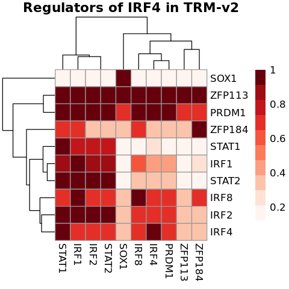

```r
options(repr.plot.width=4, repr.plot.height=4)
pheatmap(data4, color = colorRampPalette(brewer.pal(n = 9, name = "Reds"))(10), main = 'Regulators of IRF4 in TRM-v2')
```

```r
## prepare data for bar plot
data3l <- data4 |> tibble::rownames_to_column('row') |> tidyr::pivot_longer(!row,names_to = 'column', values_to = 'coverage')
head(data3l)
dim(data3l)
```

A tibble: 6 × 3

| row <chr> | column <chr> | coverage <dbl> |
| --- | --- | --- |
| SOX1 | SOX1 | 1.0000000 |
| SOX1 | ZFP113 | 0.1428571 |
| SOX1 | ZFP184 | 0.1428571 |
| SOX1 | IRF1 | 0.1428571 |
| SOX1 | IRF2 | 0.1428571 |
| SOX1 | IRF4 | 0.1428571 |

1. 100

2. 3

```r
# PRDM1 peaks cobound by other TFs
data3l1 <- data3l |> filter(row=='PRDM1') |> arrange(coverage)
data3l1$column <- factor(data3l1$column, levels = data3l1$column)

# TF peaks cobound by PRDM1
data3l2 <- data3l |> filter(column=='PRDM1') |> arrange(coverage)
data3l2$row <- factor(data3l2$row, levels = data3l2$row)
```

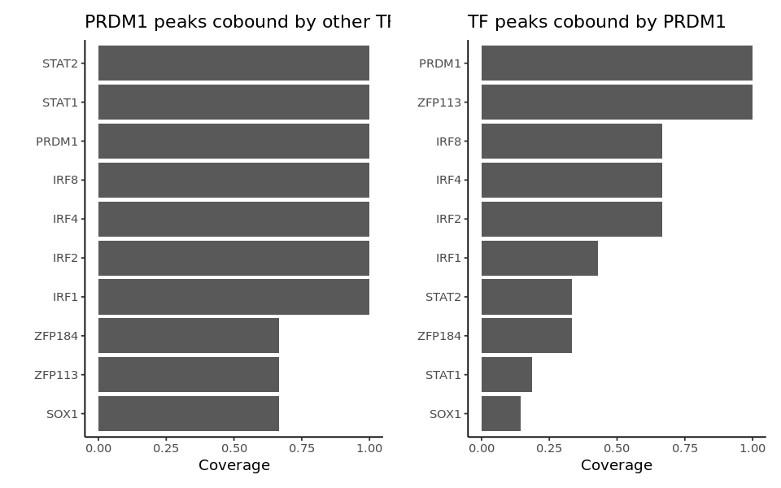

```r
options(repr.plot.width=8, repr.plot.height=5)
p2 <- ggplot(data = data3l1, aes(x=coverage, y=column)) + geom_col() + theme_classic() + labs(x='Coverage',y='',title='PRDM1 peaks cobound by other TFs')
p3 <- ggplot(data = data3l2, aes(x=coverage, y=row)) + geom_col() + theme_classic() + labs(x='Coverage',y='', title='TF peaks cobound by PRDM1')
p2+p3
```

[figure not shown]

```r
pheatmap(data3, color = colorRampPalette(brewer.pal(n = 9, name = "Reds"))(10), main = 'Regulators of IRF4 in TRM')
```

```r
# define function v2: add TF of interest
get_tf_correlation_v2 <- function(sample,regulatee,add_tfs){
    df <- read.csv(paste0('edge_weight_per_locus_all_',sample,'.csv'))
    candidateTFs <- df |> filter(X.END_ID == regulatee) |> group_by(X.START_ID) |> summarise(n=n()) |> slice_max(order_by = n, n=30, with_ties = T) |> pull(X.START_ID) ## select the top 10 TFs with most binding sites

    # add TF of interest
    candidateTFs <- union(candidateTFs,add_tfs)

    get_tf_corr_helper <- function(tf1, tf2){
        df1 <- df |> filter(X.END_ID == regulatee & X.START_ID == tf1) |> select(chr, start.int, end.int)
        names(df1) <- c('chrom','start','end')
        df2 <- df |> filter(X.END_ID == regulatee & X.START_ID == tf2) |> select(chr, start.int, end.int)
        names(df2) <- c('chrom','start','end')
        df3 <- bed_intersect(df1, df2) |> filter(.overlap>0) |> distinct(chrom, start.x, end.x)
        dim(df3)[1]/dim(df1)[1]
    }
    data <- mapply(get_tf_corr_helper, rep(candidateTFs, each = length(candidateTFs)), rep(candidateTFs, length(candidateTFs)))
    data2 <- data.frame('tf1' = rep(candidateTFs, each = length(candidateTFs)),
                    'tf2' = rep(candidateTFs, length(candidateTFs)),
                    'cov' = unlist(data)) |> tidyr::pivot_wider(names_from = 'tf2', values_from = 'cov') |> tibble::column_to_rownames('tf1')

    return(data2)
}
```

```r
data3 <- get_tf_correlation_v2('TRM','IRF4',c('PRDM1'))
```

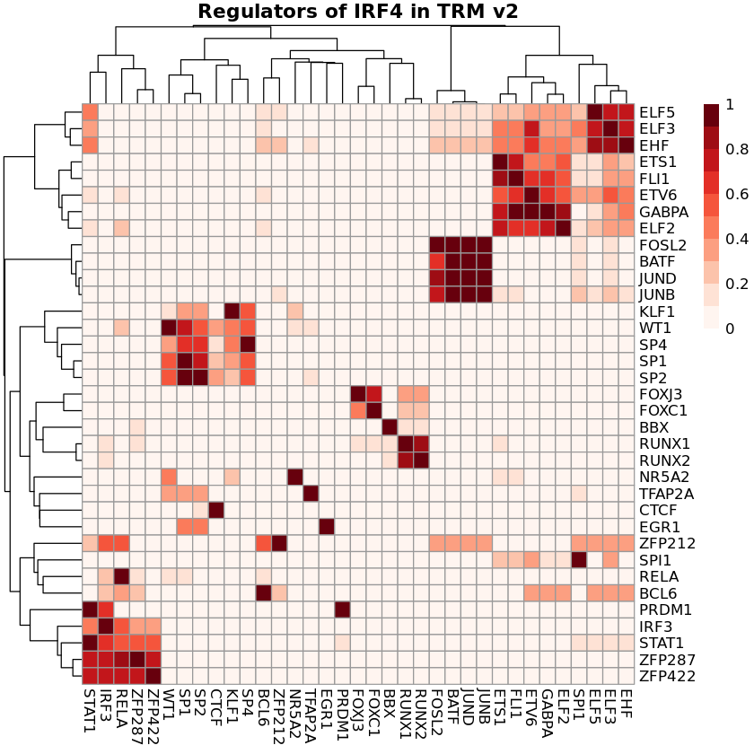

```r
pheatmap(data3, color = colorRampPalette(brewer.pal(n = 9, name = "Reds"))(10), main = 'Regulators of IRF4 in TRM v2')
```